# Stat 480 - Homework #7

3/1/2018

## Star Wars

1. Download the RMarkdown file with these homework instructions to use as a template for your work. Make sure to replace “Your Name” in the YAML with your name.
2. We are back to a survey collected by FiveThirtyEight. This time we are interested in a survey on Star Wars - the accompanying article is published [here](https://fivethirtyeight.com/features/americas-favorite-star-wars-movies-and-least-favorite-characters/)

```r
library(tidyverse)
starwars <- read_csv("https://raw.githubusercontent.com/fivethirtyeight/data/master/star-wars-survey/StarWars.csv")

# the following lines are necessary to make the second line of the file
# part of the names:
line1 <- names(starwars)
line2 <- unlist(starwars[1,])
varnames <- paste(line1, line2)
# clean up some of the multibyte characters:
names(starwars) <- enc2native(stringi::stri_trans_general(varnames, "latin-ascii"))

starwars <- starwars[-1,]
```

3. How many people respondent to the survey? How many people have seen at least one of the movies? Use the variable `Have you seen any of the 6 films in the Star Wars franchise? Response` to answer this question. Only consider responses of participants who have seen at least one of the Star Wars films for the remainder of the homework.
   - 1,186 people responded to the survey.
   - 936 people have seen at least one of the Star Wars films.

```r
dim(starwars)
```

```
## [1] 1186   38
```

```r
starwars1 <- starwars %>% filter(`Have you seen any of the 6 films in the Star Wars franchise? Response` == "Yes")
dim(starwars1)
```

```
## [1] 936  38
```

4. Variables `Gender Response` and `Age Response` are two of the demographic variables collected. Use `dplyr` to provide a frequency break down for each variable. Does the result surprise you? Comment. Reorder the levels in the variable `Age Response` from youngest to oldest.
   - Yes, this does surprise me; I expected the highest frequency to come from people of age 18-29, not 45-60. I also expected much fewer people older than 60.

```r
starwars1 %>%
  group_by(`Gender Response`, `Age Response`) %>%
  summarise(freq = n())
```

```
## # A tibble: 9 x 3
## # Groups:   Gender Response [?]
##   `Gender Response` `Age Response`  freq
##   <chr>             <chr>          <int>
## 1 Female            > 60              99
## 2 Female            18-29             85
## 3 Female            30-44             93
## 4 Female            45-60            120
## 5 Male              > 60              94
## 6 Male              18-29             95
## 7 Male              30-44            114
## 8 Male              45-60            120
## 9 <NA>              <NA>             116
```

```r
starwars1 %>%
  group_by(`Gender Response`, `Age Response`) %>%
  summarise(freq = n()) %>%
  mutate(`Age Response` = factor(`Age Response`, levels = c("18-29", "30-44", "45-60", "> 60"))) %>%
  arrange(`Gender Response`, `Age Response`)
```

```
## # A tibble: 9 x 3
## # Groups:   Gender Response [3]
##   `Gender Response` `Age Response`  freq
##   <chr>             <fct>          <int>
## 1 Female            18-29             85
## 2 Female            30-44             93
## 3 Female            45-60            120
## 4 Female            > 60              99
## 5 Male              18-29             95
## 6 Male              30-44            114
## 7 Male              45-60            120
## 8 Male              > 60              94
## 9 <NA>              <NA>             116
```

5. Variables 10 through 15 answer the question: “Please rank the Star Wars films in order of preference with 1 being your favorite film in the franchise and 6 being your least favorite film.” for each of the films. Use `dplyr` to find the average rank for each of the films (Note: you will first have to cast the responses to numbers). Are average ranks different between the mens’ and womens’ rankings? On how many responses are the averages based? Show these numbers together with the averages.
   - Males tend to favor all films more than females do, except for “Episode I: The Phantom Menace” and “Episode II: Attack of the Clones”. However, these numbers could very well possibly be skewed since there are missing values.
   - 397 females ranked each film and 423 males ranked each film. 116 respondents failed to provide their gender.

```r
starwars1 %>%
  mutate(`Please rank the Star Wars films in order of preference with 1 being your favorite film in the franchise and 6 being your least favorite film. Star Wars: Episode I  The Phantom Menace` = as.numeric(as.character(`Please rank the Star Wars films in order of preference with 1 being your favorite film in the franchise and 6 being your least favorite film. Star Wars: Episode I  The Phantom Menace`))) %>%
  mutate(`X11 Star Wars: Episode II  Attack of the Clones` = as.numeric(as.character(`X11 Star Wars: Episode II  Attack of the Clones`))) %>%
  mutate(`X12 Star Wars: Episode III  Revenge of the Sith` = as.numeric(as.character(`X12 Star Wars: Episode III  Revenge of the Sith`))) %>%
  mutate(`X13 Star Wars: Episode IV  A New Hope` = as.numeric(as.character(`X13 Star Wars: Episode IV  A New Hope`))) %>%
  mutate(`X14 Star Wars: Episode V The Empire Strikes Back` = as.numeric(as.character(`X14 Star Wars: Episode V The Empire Strikes Back`))) %>%
  mutate(`X15 Star Wars: Episode VI Return of the Jedi` = as.numeric(as.character(`X15 Star Wars: Episode VI Return of the Jedi`))) %>%
  select(`Please rank the Star Wars films in order of preference with 1 being your favorite film in the franchise and 6 being your least favorite film. Star Wars: Episode I  The Phantom Menace`, `X11 Star Wars: Episode II  Attack of the Clones`,
         `X12 Star Wars: Episode III  Revenge of the Sith`,
         `X13 Star Wars: Episode IV  A New Hope`, `X14 Star Wars: Episode V The Empire Strikes Back`, `X15 Star Wars: Episode VI Return of the Jedi`) %>%
  rename(`Star Wars: Episode I  The Phantom Menace` = `Please rank the Star Wars films in order of preference with 1 being your favorite film in the franchise and 6 being your least favorite film. Star Wars: Episode I  The Phantom Menace`,
         `Star Wars: Episode II  Attack of the Clones` = `X11 Star Wars: Episode II  Attack of the Clones`,
         `Star Wars: Episode III  Revenge of the Sith`= `X12 Star Wars: Episode III  Revenge of the Sith`,
         `Star Wars: Episode IV  A New Hope` = `X13 Star Wars: Episode IV  A New Hope`,
         `Star Wars: Episode V The Empire Strikes Back` = `X14 Star Wars: Episode V The Empire Strikes Back`,
         `Star Wars: Episode VI Return of the Jedi` = `X15 Star Wars: Episode VI Return of the Jedi`) %>%
  gather(film, rank) %>%
  group_by(film) %>%
  summarise(mean_rank = mean(rank, na.rm = TRUE),
            responses = n())
```

```
## # A tibble: 6 x 3
##   film                                         mean_rank responses
##   <chr>                                            <dbl>     <int>
## 1 Star Wars: Episode I  The Phantom Menace          3.73       936
## 2 Star Wars: Episode II  Attack of the Clones       4.09       936
## 3 Star Wars: Episode III  Revenge of the Sith       4.34       936
## 4 Star Wars: Episode IV  A New Hope                 3.27       936
## 5 Star Wars: Episode V The Empire Strikes Back      2.51       936
## 6 Star Wars: Episode VI Return of the Jedi          3.05       936
```

```r
film_pref <- starwars1 %>%
  mutate(`Please rank the Star Wars films in order of preference with 1 being your favorite film in the franchise and 6 being your least favorite film. Star Wars: Episode I  The Phantom Menace` = as.numeric(as.character(`Please rank the Star Wars films in order of preference with 1 being your favorite film in the franchise and 6 being your least favorite film. Star Wars: Episode I  The Phantom Menace`))) %>%
  mutate(`X11 Star Wars: Episode II  Attack of the Clones` = as.numeric(as.character(`X11 Star Wars: Episode II  Attack of the Clones`))) %>%
  mutate(`X12 Star Wars: Episode III  Revenge of the Sith` = as.numeric(as.character(`X12 Star Wars: Episode III  Revenge of the Sith`))) %>%
  mutate(`X13 Star Wars: Episode IV  A New Hope` = as.numeric(as.character(`X13 Star Wars: Episode IV  A New Hope`))) %>%
  mutate(`X14 Star Wars: Episode V The Empire Strikes Back` = as.numeric(as.character(`X14 Star Wars: Episode V The Empire Strikes Back`))) %>%
  mutate(`X15 Star Wars: Episode VI Return of the Jedi` = as.numeric(as.character(`X15 Star Wars: Episode VI Return of the Jedi`))) %>%
  select(`Gender Response`, `Please rank the Star Wars films in order of preference with 1 being your favorite film in the franchise and 6 being your least favorite film. Star Wars: Episode I  The Phantom Menace`, `X11 Star Wars: Episode II  Attack of the Clones`,
         `X12 Star Wars: Episode III  Revenge of the Sith`,
         `X13 Star Wars: Episode IV  A New Hope`, `X14 Star Wars: Episode V The Empire Strikes Back`, `X15 Star Wars: Episode VI Return of the Jedi`) %>%
  rename(Gender = `Gender Response`, `Episode I  The Phantom Menace` = `Please rank the Star Wars films in order of preference with 1 being your favorite film in the franchise and 6 being your least favorite film. Star Wars: Episode I  The Phantom Menace`,
         `Episode II  Attack of the Clones` = `X11 Star Wars: Episode II  Attack of the Clones`,
         `Episode III  Revenge of the Sith`= `X12 Star Wars: Episode III  Revenge of the Sith`,
         `Episode IV  A New Hope` = `X13 Star Wars: Episode IV  A New Hope`,
         `Episode V The Empire Strikes Back` = `X14 Star Wars: Episode V The Empire Strikes Back`,
         `Star Wars: Episode VI Return of the Jedi` = `X15 Star Wars: Episode VI Return of the Jedi`) %>%
  gather(film, rank, -Gender) %>%
  group_by(Gender, film) %>%
  summarise(mean_rank = mean(rank, na.rm = TRUE),
            responses = n())
film_pref
```

```
## # A tibble: 18 x 4
## # Groups:   Gender [?]
##    Gender film                                     mean_rank responses
##    <chr>  <chr>                                        <dbl>     <int>
##  1 Female Episode I  The Phantom Menace                 3.43       397
##  2 Female Episode II  Attack of the Clones              3.95       397
##  3 Female Episode III  Revenge of the Sith              4.42       397
##  4 Female Episode IV  A New Hope                        3.54       397
##  5 Female Episode V The Empire Strikes Back             2.57       397
##  6 Female Star Wars: Episode VI Return of the Jedi      3.08       397
##  7 Male   Episode I  The Phantom Menace                 4.04       423
##  8 Male   Episode II  Attack of the Clones              4.22       423
##  9 Male   Episode III  Revenge of the Sith              4.27       423
## 10 Male   Episode IV  A New Hope                        3.00       423
## 11 Male   Episode V The Empire Strikes Back             2.46       423
## 12 Male   Star Wars: Episode VI Return of the Jedi      3.00       423
## 13 <NA>   Episode I  The Phantom Menace                 3.19       116
## 14 <NA>   Episode II  Attack of the Clones              3.75       116
## 15 <NA>   Episode III  Revenge of the Sith              4.19       116
## 16 <NA>   Episode IV  A New Hope                        3.81       116
## 17 <NA>   Episode V The Empire Strikes Back             2.56       116
## 18 <NA>   Star Wars: Episode VI Return of the Jedi      3.50       116
```

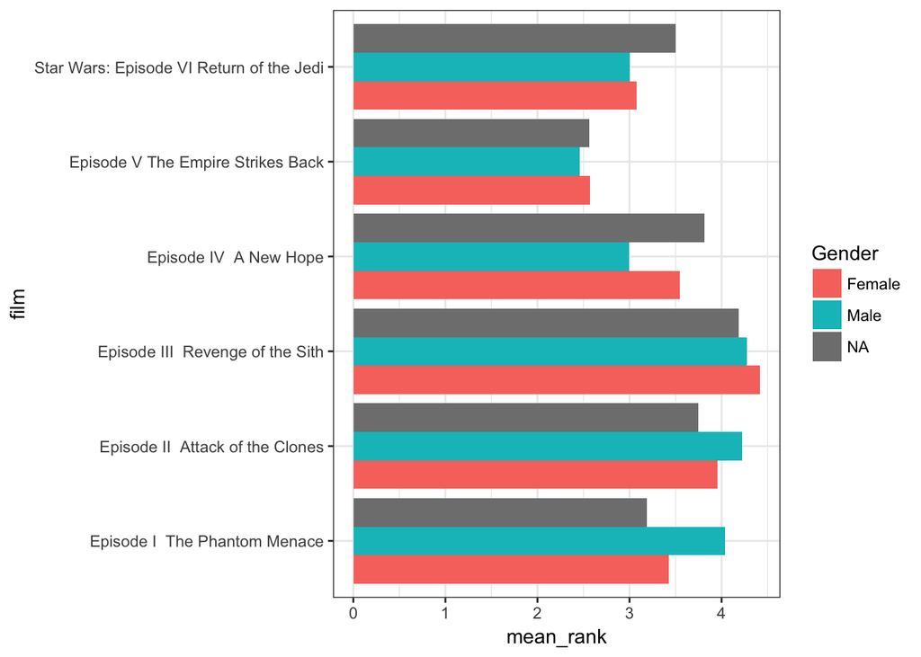

```r
ggplot(film_pref, aes(x = film, y = mean_rank)) +
  geom_bar(aes(fill = Gender), position = "dodge", stat = "identity") +
  theme_bw() +
  coord_flip()
```

6. R2 D2 or C-3P0? Which of these two characters is the more popular one? Use responses to variables 25 and 26 to answer this question. Note: first you need to define “popularity” based on the available data.
   - If “popularity” is defined by counting the proportion of respondents who selected “Very favorably” or “Somewhat favorably”, it appears as if R2 D2 is more popular.
   - If “popularity” is defined by counting the proportion of respondents who selected “Very favorably”, it appears that R2 D2 is again more popular.

```r
starwars1 %>%
  mutate(favors_C3P0 = ifelse(`X25 C-3P0` == "Very favorably" | `X25 C-3P0` == "Somewhat favorably", 1, 0),
         favors_R2D2 = ifelse(`X26 R2 D2` == "Very favorably" | `X26 R2 D2` == "Somewhat favorably", 1, 0)) %>%
  select(favors_C3P0, favors_R2D2) %>%
  gather(char, favors) %>%
  group_by(char) %>%
  summarise(mean_favorability = mean(favors, na.rm = TRUE))
```

```
## # A tibble: 2 x 2
##   char        mean_favorability
##   <chr>                   <dbl>
## 1 favors_C3P0             0.850
## 2 favors_R2D2             0.900
```

```r
starwars1 %>%
  mutate(favors_C3P0 = ifelse(`X25 C-3P0` == "Very favorably", 1, 0),
         favors_R2D2 = ifelse(`X26 R2 D2` == "Very favorably", 1, 0)) %>%
  select(favors_C3P0, favors_R2D2) %>%
  gather(char, favors) %>%
  group_by(char) %>%
  summarise(mean_favorability = mean(favors, na.rm = TRUE))
```

```
## # A tibble: 2 x 2
##   char        mean_favorability
##   <chr>                   <dbl>
## 1 favors_C3P0             0.573
## 2 favors_R2D2             0.677
```

Due date: the homework is due before class on Thursday.

For the submission: submit your solution in an R Markdown file and (just for insurance) submit the corresponding html file with it.